# Workflow task manager and process administration add-on

Radiant Logic

# Introduction

## Context

> This document describes how to install and use the “Workflow task manager and process administration” add-on that allows to manage tasks that rely on the workflow engine through the web portal. In addition, this document details the functional coverage of this add-on.

> This add-on is also available for download in the RadiantOne Identity Analytics Marketplace website using the following URL:

> https://marketplace.radiantlogic.com/package/bw_task_manager/

> This document does not pretend to describe workflows’ creation, configuration, operating principle and more generally to detail iGRC studio’s functionalities.

> A full documentation that deals with Workflow is available in the developer documentation website using the following URL:

> https://developer.radiantlogic.com/ia/descartes/igrc-platform/workflow/

> And more generally, the full documentation that deals with iGRC studio is available using the following URL:

> https://developer.radiantlogic.com/ia/descartes/#1

# Task manager & process administration add-on description

## Add-on functionalities

This add-on contains the **task manager** page, the **process administration** page and also the **tickets log manager** page.

It is required if you intend to leverage the workflow features of RadiantOne Identity Analytics.

**Task manager** is a “state of the art” workflow task manager. Through this application, your users can browse their assigned tasks, take, release and reassign tasks, send mails to the stakeholders, and more.

As a functional process administrator, you can browse and manage your own tasks.

This means you can from the **task manager** page:

- View from your “inbox” your pending tasks details and take or release them,
- View the lists of your on-going tasks,
- Launch new process instances,
- View the details of your archived tasks.

**Process administration** page goes further on your process instances and allows you to:

- View and manage your active processes,
- View the details of your archived processes,
- Get an overview on your tasks in error, the error messages with the possibility to ignore or relaunch them.

**Tickets log manager** page allows you to view all the created tickets and to download compliance reports. It also allows you in test mode to follow up and remove tickets logs to clear the workflow database.

**WARNING:** do not use this deletion option in production, only in development environment, since it has an impact on the compliance reports generation and the workflow database history.

## New features

Among the new features:

- Tickets management:

The use of tickets allows to considerably improve the display of information in the **task manager** and the **process administration** pages.

**WARNING:** now the use of tickets is mandatory, so you need to activate the tickets "ticketlogs" and "ticketaction" in the configuration of your old workflow files or when you configure new workflows.

When you activate the the “Mark tickets as test to be able to delete them” in your technical configuration, you can view and delete tickets logs that have been marked as “debug” from your **tickets log manager** page. Do not use this option in production, only in development environment, since it has an impact on the compliance reports generation and the workflow database history.

- Add candidates :

The button « Reassign tasks » as been changed to « Add candidates » to be able to assign tasks to a pool of candidates.

Once the task is taken by one of the candidates or one of his delegatee, the other candidates have not access to it anymore.

And also:

- Performances have been greatly improved, allowing to manage and follow-up thousands of tasks.
- Status of the tasks have been updated. Completed and terminated tasks, which means tasks that have been manually killed, are now differentiated.
- The Process Admin interface has been updated with a new tab: "Error tasks", that allows to investigate on error messages on tasks and a new feature: "Add Candidate" has been added for the administrator.

## Pre-requisites

Compatibility matrix

Starting version 2017 R2 SP2

Versions: bw_task_manager_2.8 add-ons and upper.

All the add-on versions are available in the marketplace website using URL: https://marketplace.radiantlogic.com/package/bw_task_manager/

This add-on has no dependency.

## Add-on content

This add-on contains workflow files to manage tasks as well as the associated tickets that allow to follow up the task status. These files are available at format « .workflow » and are provided with a .javascript file.

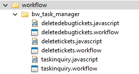

Dashboards are also provided to allow the end-user to view his tasks, manage them, and when permitted create new process instances and administrate them. These dashboards are files available at format « .page »

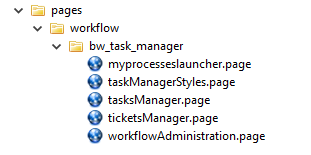

Views are also available to provide data display in dashboards and pages:

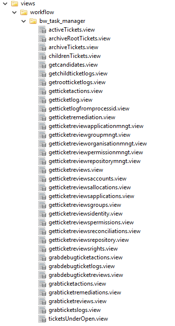

Finally, this add-on provides also a set of features, featuresets and menitems files that allows to manage the access rights to the **task manager**, **process administration** and **tickets log manager** features:

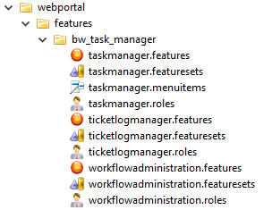

# Task manager & process administration add-on installation procedure

## Installation procedure

The add-on is available as a “.facet” format file, which is managed natively by the RadiantOne Identity Analytics studio. It eases installation, updates and remove of the add-on in RadiantOne Identity Analytics projects.

To install the add-on, from the iGRC studio open the project configuration window using the left menu w by clicking on « Show project configuration".

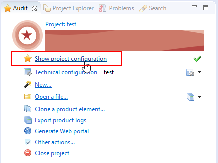

Select the bottom tab « Facets » and click on the ‘plus’ button to add an add-on.

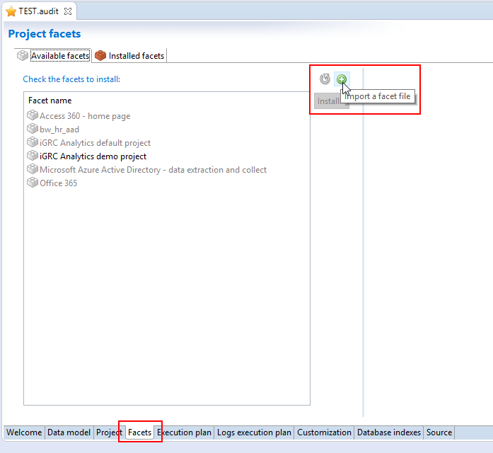

Then select the add-on in the related directory and click on OK:

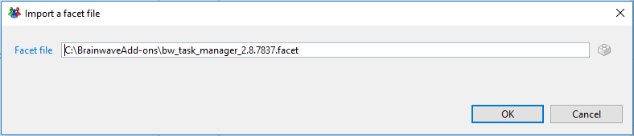

In the tab « Available facets», select the add-on to install and click on the « install… » button:

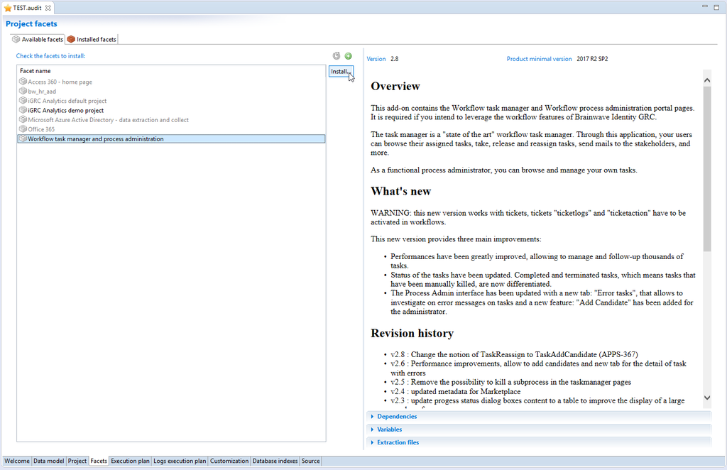

A pop-up window opens, describing all the files that will be installed during the procedure.

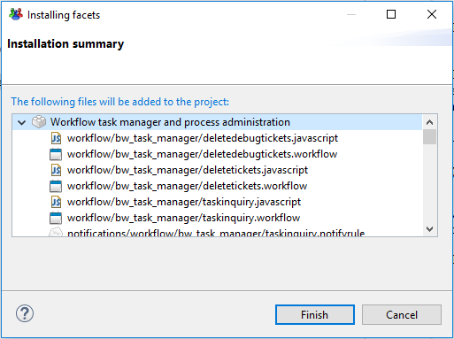

Click on “Finish” to proceed.

## Configuration

This add-on installs three new "admin pages". In order to access to those pages you need to have access to the 'admin section' through the menu admin feature or igrcadmin featureset and one of the taskmanager featureset (see 4.1 Task manager & process administration profiles & roles for a description of the different profiles)

Three roles files are also provided for test and demonstration purposes only. You should remove those files prior to go into production and you should attach your project roles to the right featuresets.

**WARNING**: this new version works with tickets, tickets "ticketlogs" and "ticketaction" must be activated in workflows.

When you activate the “Mark tickets as test to be able to delete them” in your technical configuration, you can view and delete tickets logs that have been marked as “debug” from your **tickets log manager** page. Do not use this option in production, only in development environment, since it has an impact on the compliance reports generation and the workflow database history.

[figure not shown]

## Add-on update and remove procedures

To update the add-on, follow the same procedure as previously to import the last version of the add-on:

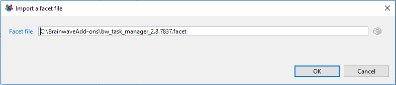

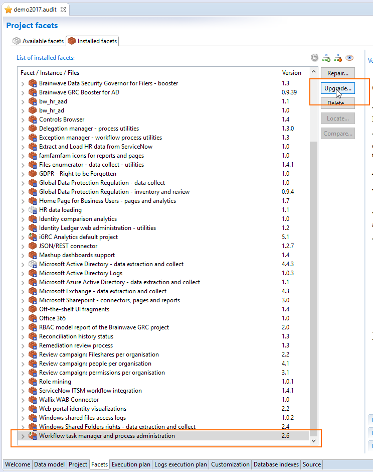

A pop-up window describes the files that will be upgraded during the procedure. By selecting “Keep replaced files…” the replaced files are kept by renaming as “.old”. Click on “Finish” to launch the upgrade.

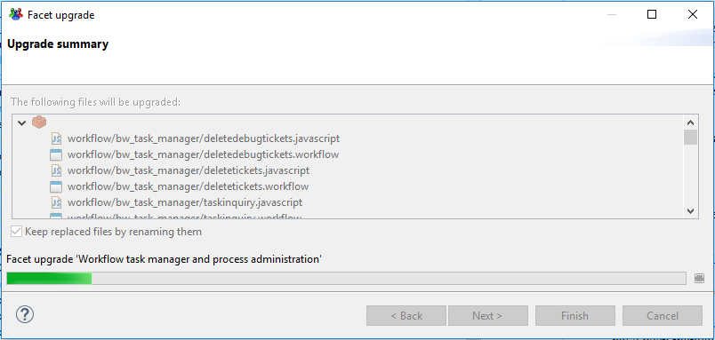

To uninstall the add-on, select it in the list then click on « Delete… ».

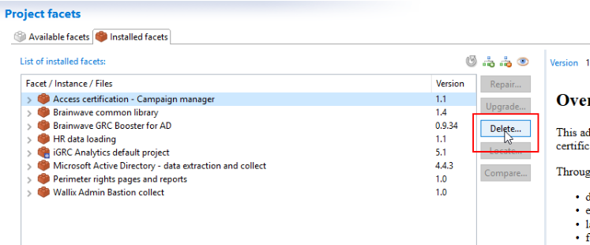

A “confirm deletion” pop-up window opens. Click on “Finish” to execute the deletion.

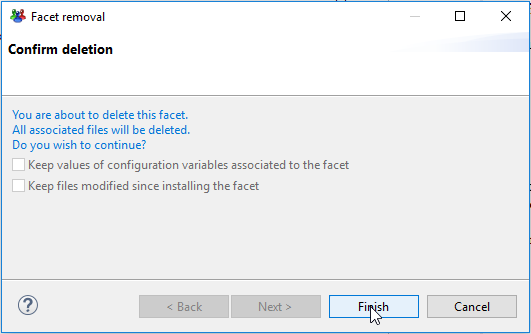

Note that after having installed or updated an add-on of type workflow, you should restart the iGRC studio and the tomcat service to consider the changes.

# Task manager & process administration functional coverage

## Task manager & process administration profiles and roles

For each page, several featuresets are provided to access to the different features of the **task manager**, the **process administration** and the **tickets log manager** pages.

The following featuresets are available for the **task manager** page in the file “taskmanager.featuresets”:

- tm_poweruser: Can launch new processes, send emails in all tabs, assign tasks to

> candidates and access to completed tasks,
- tm_standarduser: Can send emails to other candidates, cannot start new processes,
- tm_all: Access to all the **task manager** features. Poweruser ’s features and

> suspend a task, resume atask, stop processes; reassign a task to any

> individual,
- tm_limiteduser: Limited to the minimum: cannot launch new processes, can only

> acquire tasks from the inbox.

By default, this **task manager** page is available under the category “Audit” of your project, menu “Admin” from the web portal, thanks to the tag “Admin” that is used in the page:

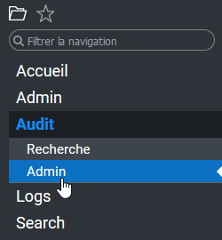

Then click on the button “Tasks manager”

Note that the access to **task manager** is then depending on the configuration of the featuresets provided in this add-on and roles available in your project. You need to associate the different featuresets to your roles by editing the “taskmanager.featuresets” file.

The following featuresets are available for the **process administration** page in the file “workflowadministration.featuresets”:

> process features),
- workflowauditor: Workflow auditor (gives an access to the workflow administration

> interfaces in read-only mode).

By default, this **process administration** page is available under the category “Audit” of your project, menu “Admin” from the web portal, thanks to the tag “Admin” that is used in the page, same as for the **task manager** page. Then you need to click on the button “Process Administration” to reach the page.

Note that the access to **process administration** is then depending on the configuration of the featuresets provided in this add-on and roles available in your project. You need to associate the different featuresets to your roles by editing the “workflowadministration.featuresets” file.

The following featuresets are available for the **tickets log manager** page in the file “ticketlogmanager.featuresets”:

- tlm_auditor: technical auditor - can access to the ticketlog manager in readonly

> mode,
- tlm_funcowner: functional owner - can access to the ticketlog manager and can

> download compliance reports,
- tlm_developer: can access to the ticketlog manager, can download compliance reports

> and can delete tickets in debug mode,
- tlm_techowner: technical owner - can access to the ticketlog manager, can download

> compliance reports and can delete any kind of ticket

By default, this **tickets log manager** page is available under the category “Audit” of your project, menu “Admin” from the web portal, thanks to the tag “Admin” that is used in the page, same as for the **task manager** page. Then you need to click on the button “Workflow Logs Manager” to reach the page.

Note that the access to **tickets log manager** is then depending on the configuration of the featuresets provided in this add-on and roles available in your project. You need to associate the different featuresets to your roles by editing the “ticketlogmanager.featuresets” file.

Here is a full description of the features available in the **task manager** page with the featuresets that give access to:

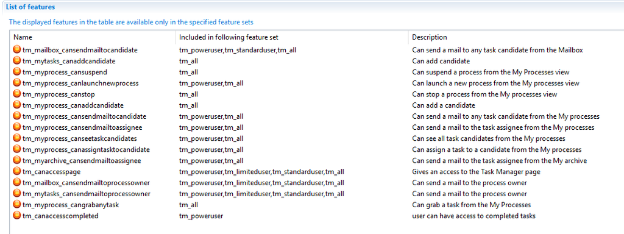

Here is a full description of the features available in the **process administration** page with the featuresets that give access to:

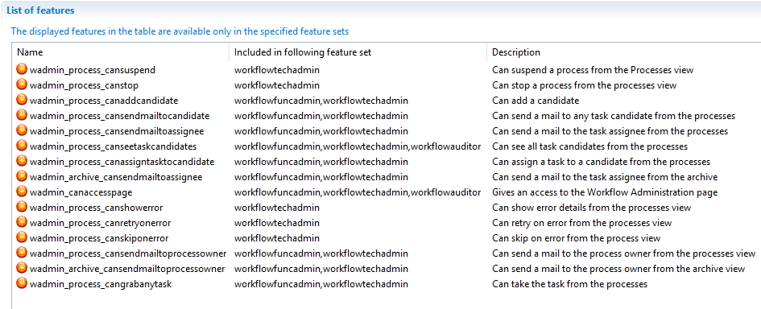

Here is a full description of the features available in the **tickets log manager** page with the featuresets that give access to:

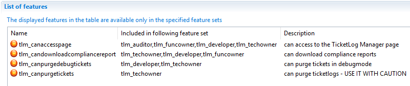

## Functionalities related to task manager page

The following part lists all the features available from the **task manager**. Please see 4.1 Task manager & process administration profiles & roles for a description of the different profiles that give access to each feature describes in this section.

From the **task manager**, you can view in the “inbox” tab the pending task with the associated candidates.

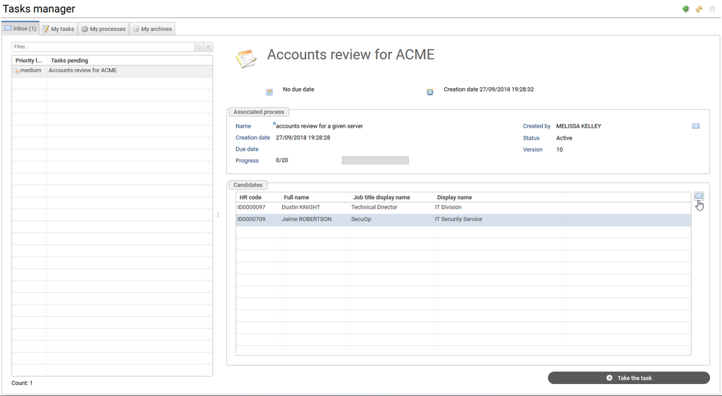

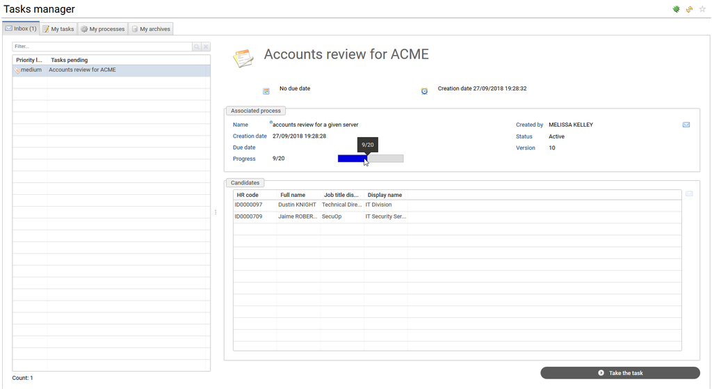

When the task is assigned to a single person, and when this person takes the task and start to work on it, the task is available by the actor from the tab “My tasks”:

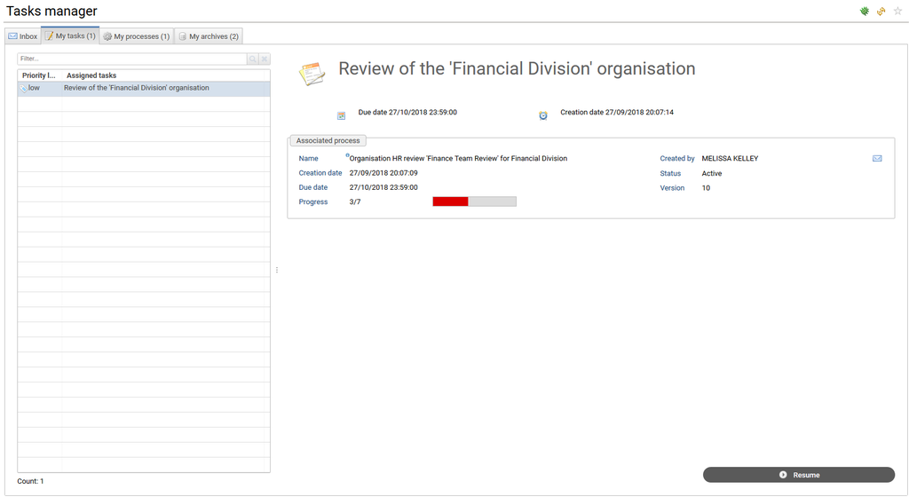

You can also in the tab “My processes” follow-up your pending process and launch new process instances:

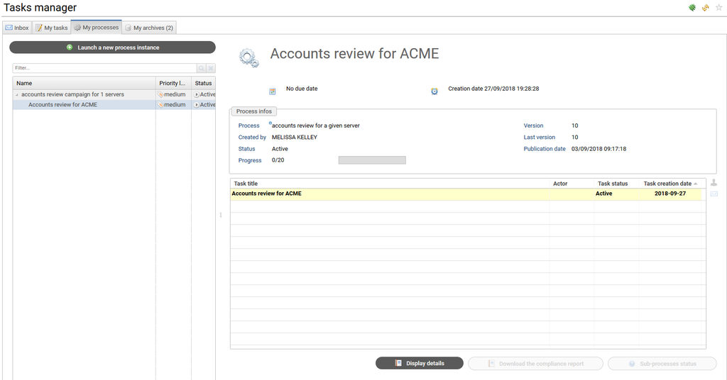

Once a new instance has been launch, you can display the candidates of your task:

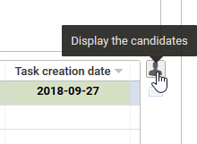

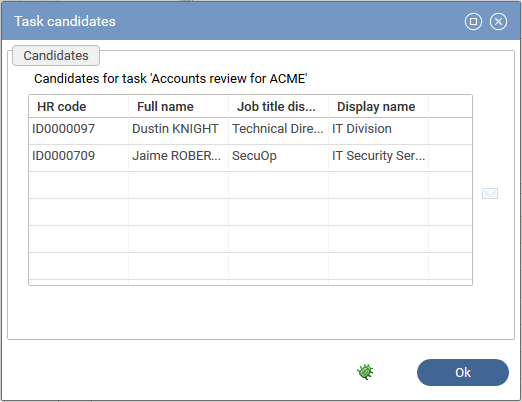

And send emails to the candidates or actors when one of the candidates take the task.

You can also view in read only mode the actor’s interface by clicking on the button “Display details”, in this example, the accounts review interface for repository ACME:

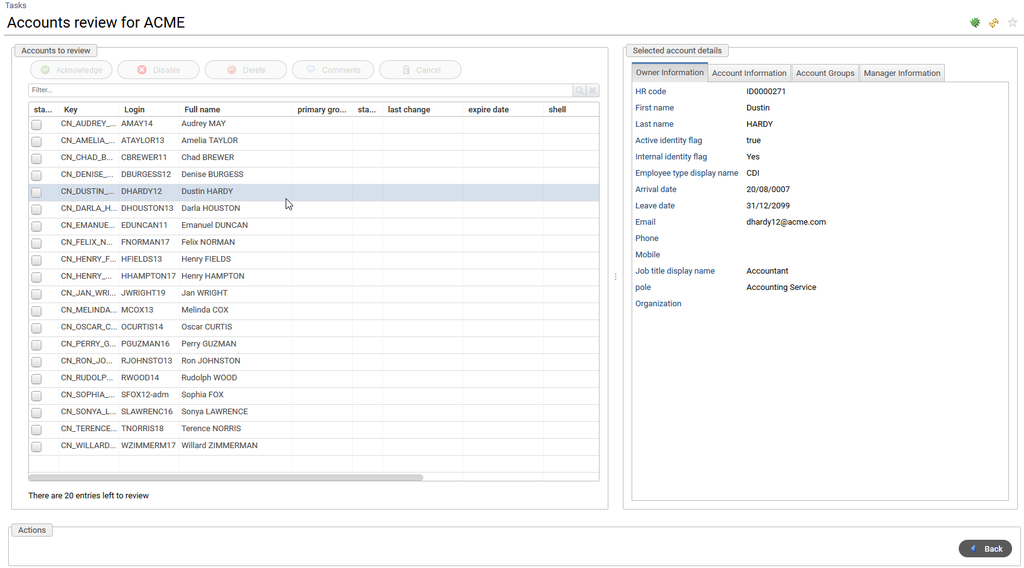

Once one of the tasks of your process has been achieved, you are able to download when relevant the compliance report by clicking on “Download the compliance report”.

When all the tasks of your process have been completed, the process will be available from the tab “My archives” with access to the synthesis report of the process, the compliance reports of sub-processes when relevant and their status.

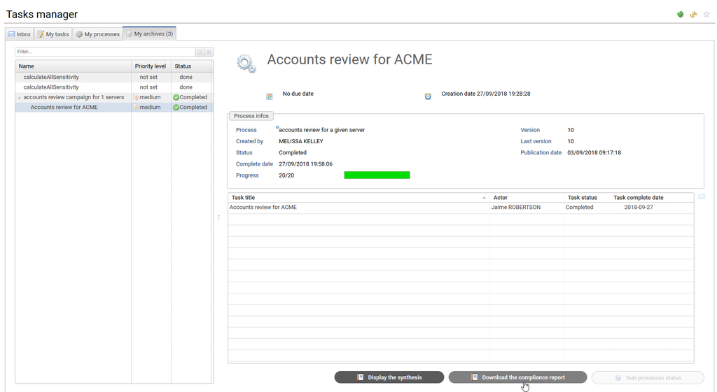

You will also have the possibility to directly send emails to the actors by clicking on the icon on the right:

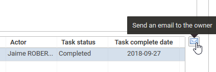

Note that even if you are process owner, to reassign a task, you need to access to the **process administration** page.

## Functionalities related to process administration page

**From “Active Processes” tab**, you can manage your different processes and sub processes and tasks.

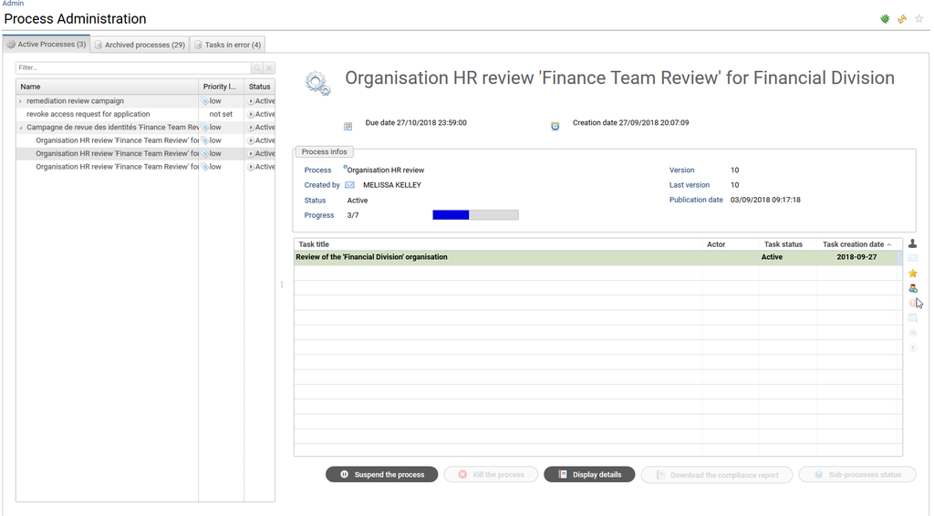

With the possibilities using the bottom buttons to suspend the process or su-process, kill the whole process, display in read-only the details of the task, download the compliance report when task has been achieved by the actor, and check sub process status:

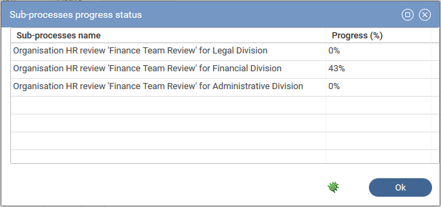

**From “Archived processes” tab**, you can get an overview on your completed or terminated processes, display the synthesis of the task, download when relevant the compliance report, get an overview on the sub-processes status and send email to task owners:

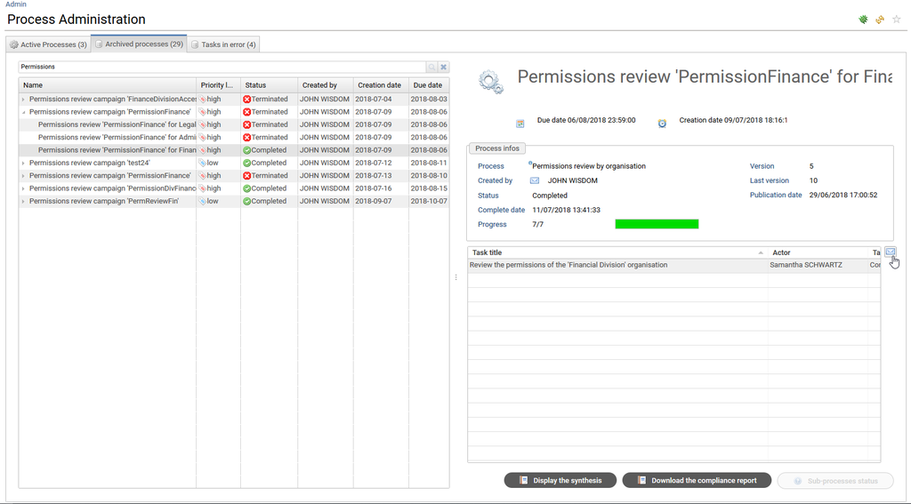

**Finally, “Tasks in error” tab** lists all the tasks which have generated errors with the possibility to retry the task on error or skip the task in error.

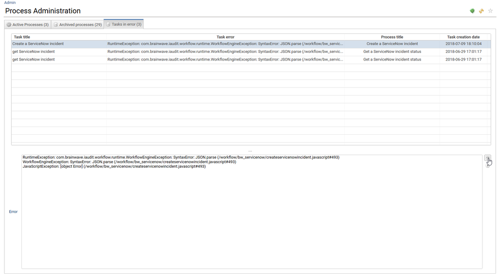

## Functionalities related to tickets log manager page

This interface is mainly used for test and development purposes, and it is strongly recommended to not use it in production environment since, depending on your roles, it allows to delete tickets in the workflow database. Typically, it allows to clean the workflow database when some tests are made during new workflows implementation.

You can delete all tickets that have been marked as debug by clicking on “Delete all debug entries” (please see 2.2 or 3.2 for the activation of debug mode in your workflow database, and 4.1 for the access rights to this feature), or simply definitely remove the selected tickets from your workflow database by clicking on “Delete entry” button.

In the table, when selecting the title of a process or subprocess, you will display on the right part all the attributes of the ticket linked to this process or sub-process. You have also the possibility to download the compliance report when available.

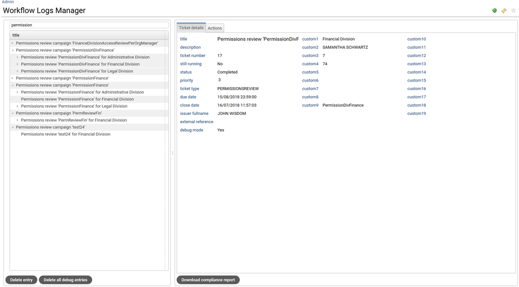

**From tab “Action”** you can display each task (or “Action”) link to the selected process or sub-process on the left.

By selecting this action, you can display in the sub tables all the reviewed objects (accounts, permissions, identities, rights etc…) with their status and for each selected item the status of the remediation ticket if you have configured also remediation workflows.

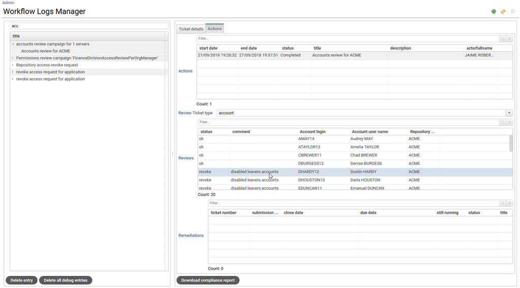

© 1995-2023 [Radiant Logic](https://developer.radiantlogic.com/)